# Distribution of Measured Variables

Pietro Franceschi | pietro.franceschi@fmach.it

## Normal Distribution

- The Normal (Gaussian) distribution has a prominent role in statistics
- Some sort of “normality” is often the prerequisite of many statistical tools
- With normal data, the mean is the value with higher probability
- Reasoning on the mean is equivalent is reasoning on the most probable value …

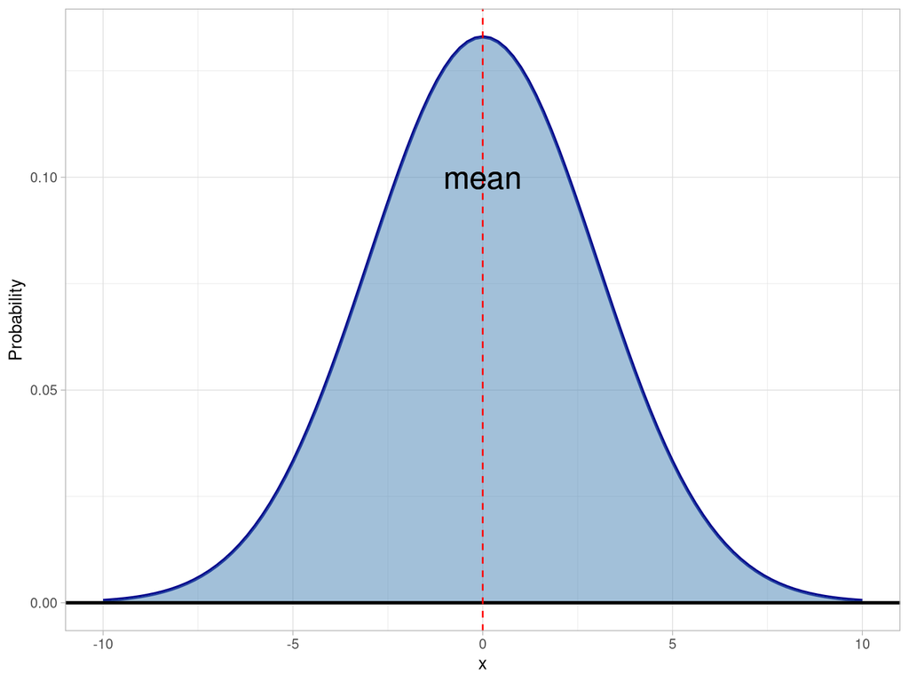

## Sampling Distribution

The distribution of the mean of a sample extracted from every type of distribution is always normal

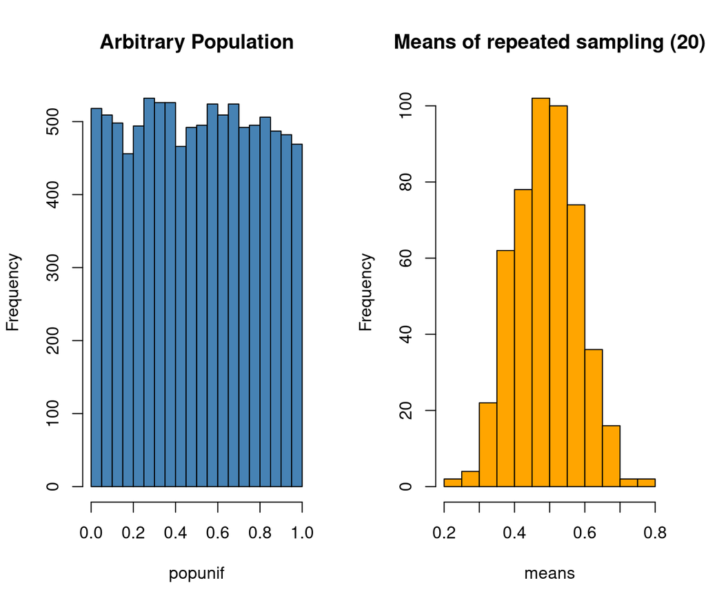

## Sampling Distribution

**Noteworthy**

1. The sampling distribution get’s narrower as the sample increases
2. This is the ultime reasons why measuring more samples leads to smaller *p-values*

## Formally

- Mean of the sampling distribution: $\mu_{pop}$
- Variance of the sampling distribution: $\frac{\sigma}{\sqrt(N)}$

Where $N$ is the size of the sample

## … but

We are often dealing with data non normally distributed

1. Count based technologies never return negative numbers … (MS!)
2. In many biochemical reactions the product of concentrations is important
3. Presence of sub-populations
4. Outliers

Sub populations are typically present in complex experiments

## Subpopulations

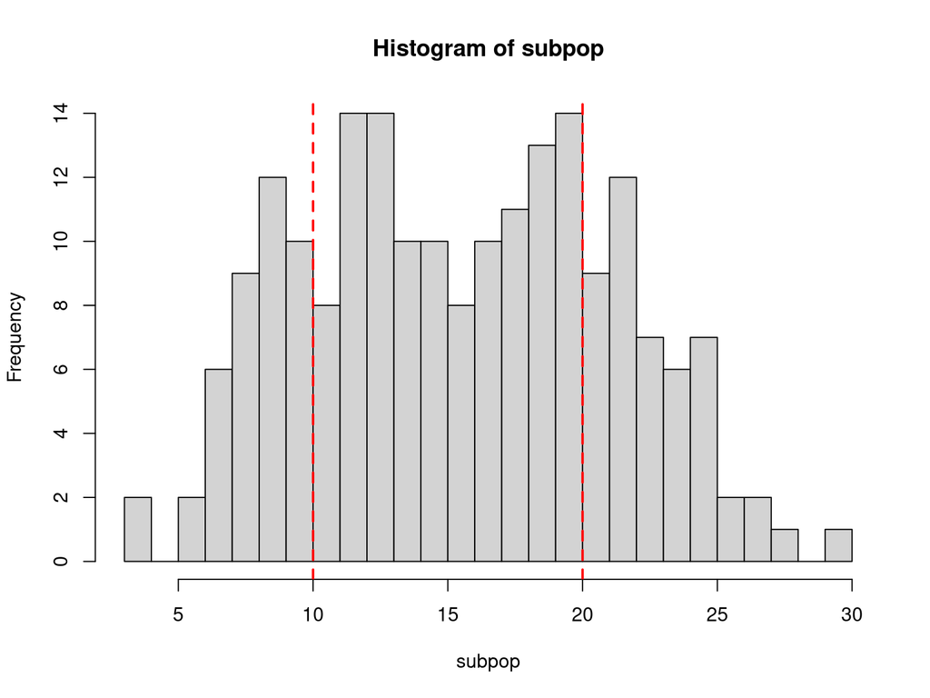

**NB: In many cases subpopulations are unknown!

## Lognormal data

Lognormal data are extremely common in metabolomics …

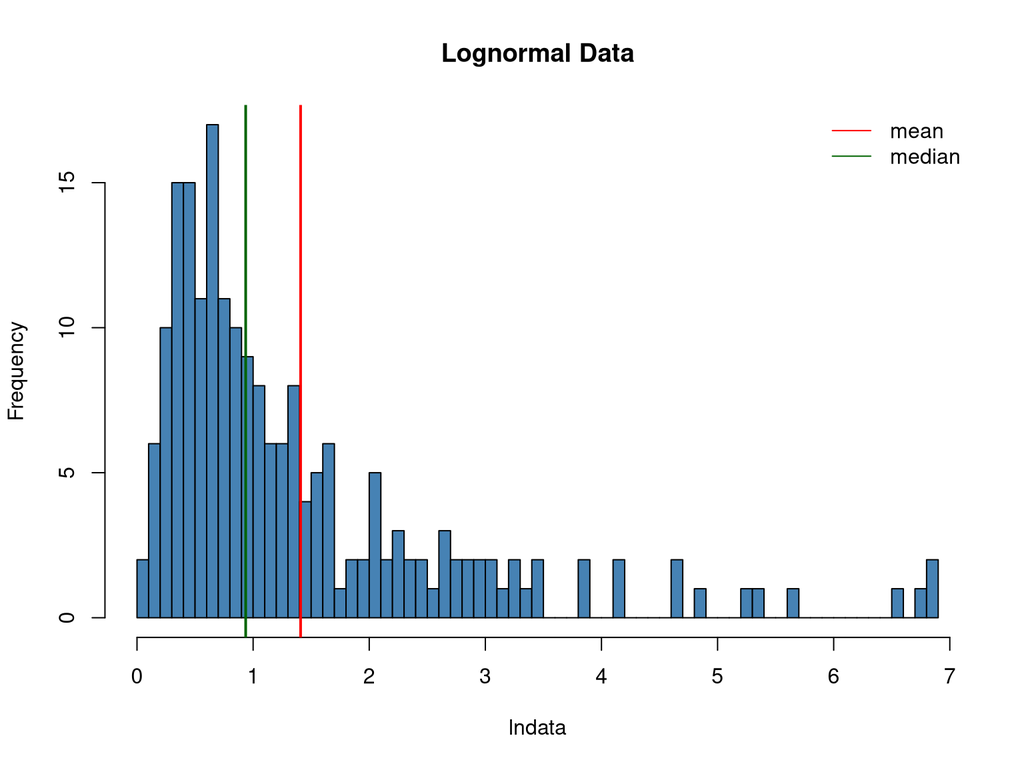

- The mean is **not** the most probable value!
- Statistical machinery focusing on **mean** is not the right tool for the trade

## Solutions

1. **Non-parametric** approaches (Kruskall-Wallis, quantile-regression, permutations, bootstrap, …)
2. Variable **transformations**

Remember that non parametric tests suffer of lack of power and are often completely useless fin investigations with only few samples (5-10)

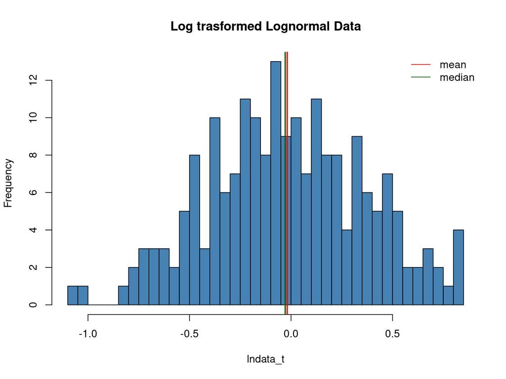

Mean and median are ok!

## Checking Normality

1. Normality tests … again statistics ;-)
2. Graphical methods `q-q plots`

## Quantile - quantile plots

Quantile quantile plots are used to visually compare the **theoretical quantiles** of a distribution with the **sample quantiles**

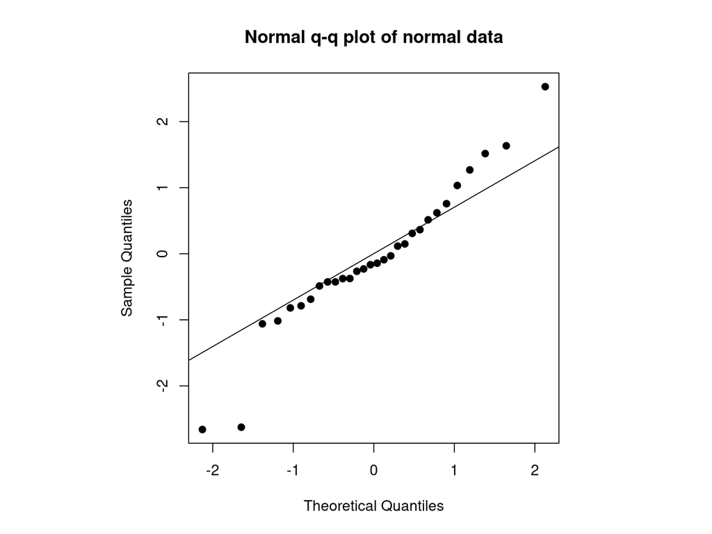

## q-q plot for lognormal data

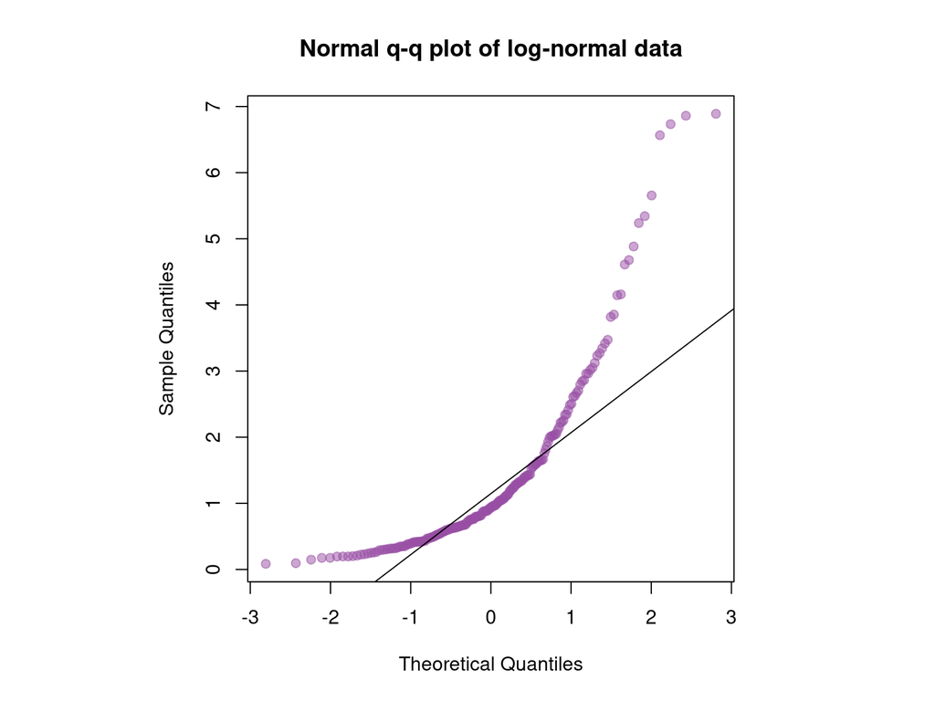

## Take home message

Before running your statistical machinery give a look to your data to check if what you are doing makes sense …